# Homework 2 ggplot

Troy Richter

2022-09-19

# Setup the code

```r
#loading the libraries
library(dplyr)
```

```r
library(readr)
library(ggplot2)
library(forcats)
library(ggridges)

#setting the theme
theme_set(theme_bw(base_size = 12))

ice <- read_csv("http://biol607.github.io/homework/data/NH_seaice_extent_monthly_1978_2016.csv") %>%
  mutate(Month_Name = factor(Month_Name),
         Month_Name = fct_reorder(Month_Name, Month))
```

# Boxplots

Make a boxplot showing the variability in sea ice extent every month IYKYK fancy

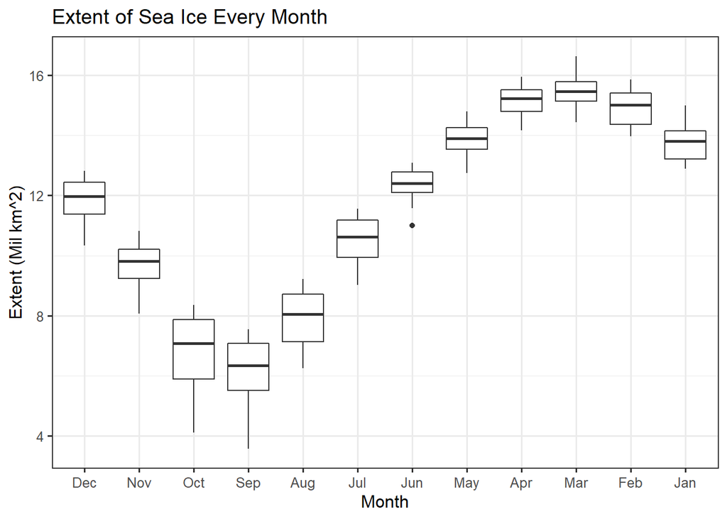

```r
ggplot(data = ice,
       mapping = aes(x = Month_Name,
       y = Extent,
       ))+
  geom_boxplot() +
  stat_boxplot() +
  scale_x_discrete(limits = rev) +
  labs(title = "Extent of Sea Ice Every Month",
       x = "Month",
       y = "Extent (Mil km^2)")
```

# Ridgelines

Use ggridges to do the same thing. What is different

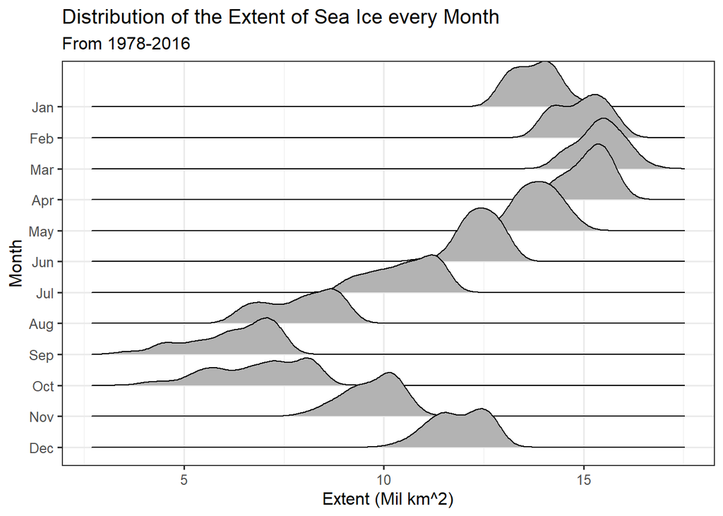

```r
#Have to flip the scale so that it started with jan
ggplot(data = ice,
       mapping = aes(x = Extent,
       y = Month_Name,
       ))+
  geom_density_ridges() +
  scale_y_discrete(limits = rev) +
  labs(title = "Distribution of the Extent of Sea Ice every Month",
       subtitle = "From 1978-2016",
       x = "Extent (Mil km^2)",
       y = "Month")
```

This interestingly did not work with the x and y flipped (months on the x). I think because it would have to show distributions in a different directions which isn’t coded.

# Making Groups from the Continuous

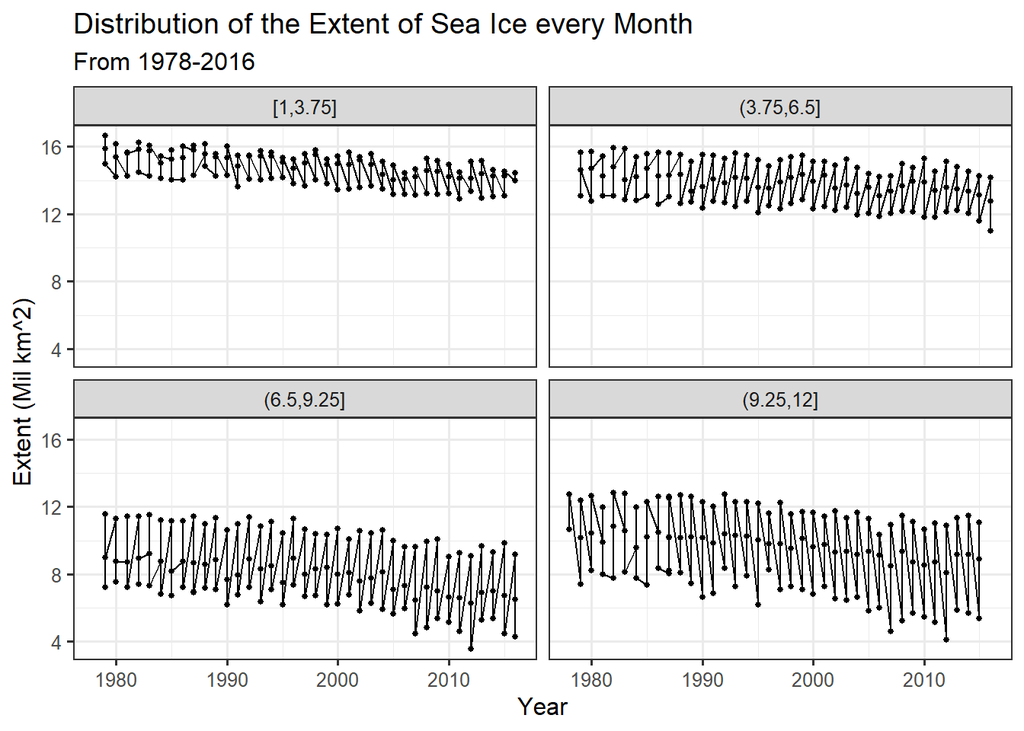

```r
ggplot(data = ice,
       mapping = aes(x = Year,
       y = Extent,
       )) +
  geom_line() +
  geom_point(size = 1) +
  #scale_y_discrete(limits = rev) +
  facet_wrap(facets = vars(cut_interval(Month, n=4), ))+
  labs(title = "Distribution of the Extent of Sea Ice every Month",
       subtitle = "From 1978-2016",
       x = "Year",
       y = "Extent (Mil km^2)")
```

# Use that color!

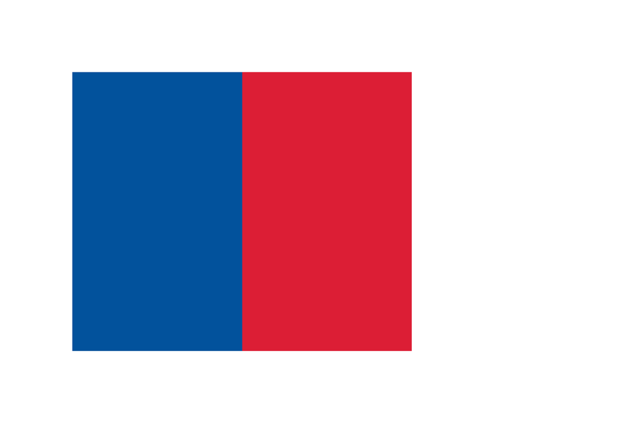

```r
#don't forget to install package install.packages("colorfindr")
library(colorfindr)

#getting colors from the Icelandic flag and plotting their hex code
iceland <- get_colors(
  img = "https://upload.wikimedia.org/wikipedia/commons/c/ce/Flag_of_Iceland.svg"
) %>%
  make_palette (n = 3)
```

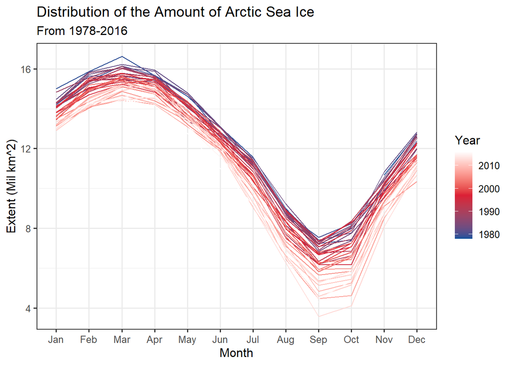

```r
# cleaning it and making it nice
ice_month <- ggplot(data = ice,
       mapping = aes(x = Month_Name,
       y = Extent)) +
  geom_line(aes(group = Year, color = Year)) +
  labs(title = "Distribution of the Amount of Arctic Sea Ice",
       subtitle = "From 1978-2016",
       x = "Month",
       y = "Extent (Mil km^2)")
#adding the Icelandic flag theme to the plot
ice_month +
  scale_color_gradientn(colors = iceland)
```

# IYKYK 1: Animating

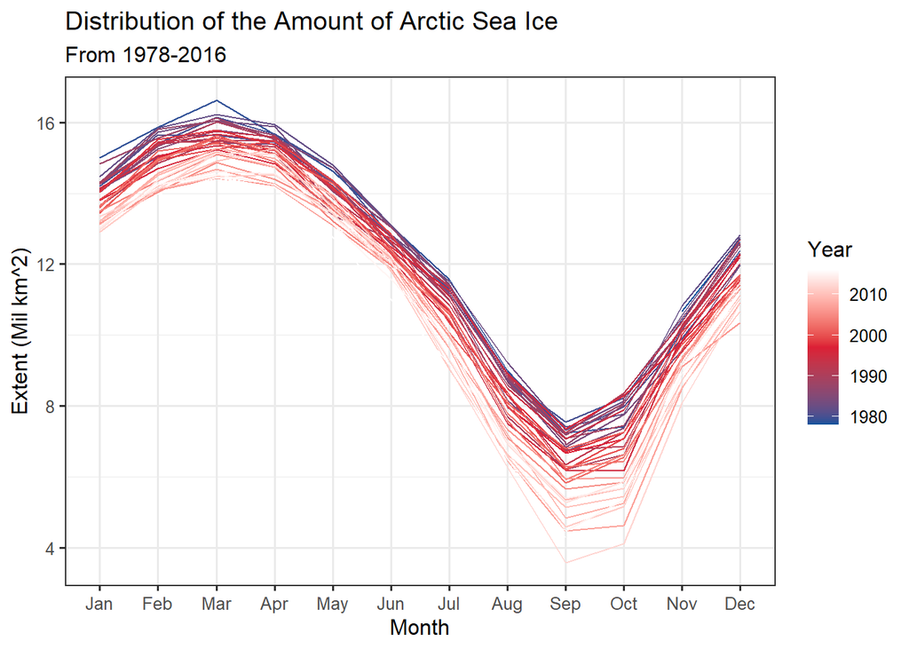

```r
#dont forget to install the packages below
library(gganimate)
library(transformr)
library(gifski)
library(png)
#plot
ice_month <- ggplot(data = ice,
       mapping = aes(x = Month_Name,
       y = Extent)) +
  geom_line(aes(group = Year, color = Year)) +
  labs(title = "Distribution of the Amount of Arctic Sea Ice",
       subtitle = "From 1978-2016",
       x = "Month",
       y = "Extent (Mil km^2)")+
  scale_color_gradientn(colors = iceland)
ice_month
```

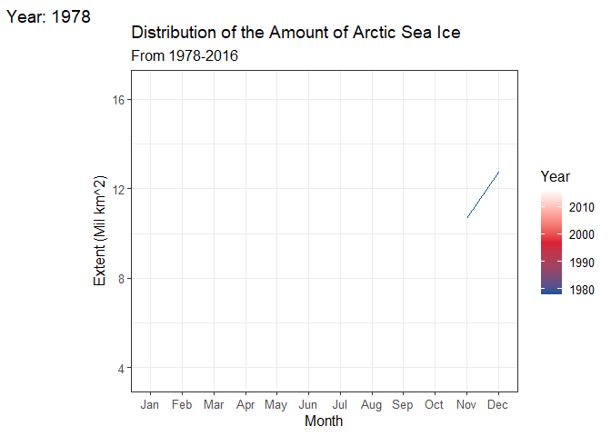

```r
#animating
ice_month_gif <- ice_month +
  transition_reveal(along =  as.integer(Year)) +
  ease_aes('linear') +
  labs(tag = "Year: {frame_along}")
animate(ice_month_gif, renderer = gifski_renderer(file = "iceland.gif"))
```

# IYKYK 2: Making something new

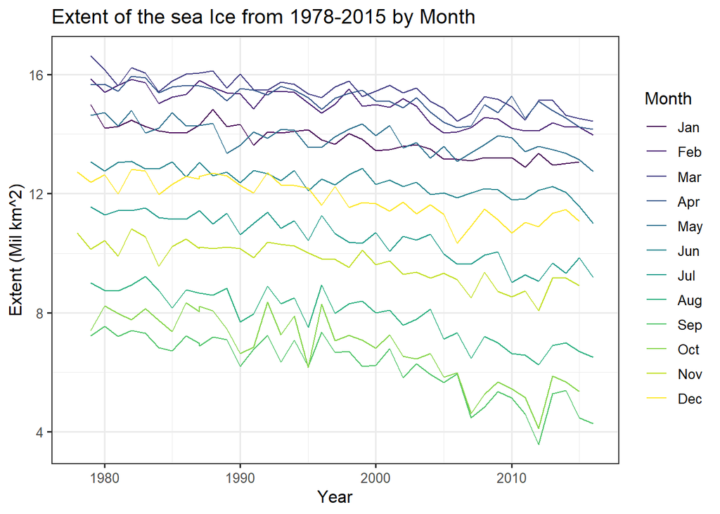

```r
ice_all <- ggplot(data= ice,
                  mapping = aes(x = Year,
                                y = Extent))+
  geom_line(aes(group = Month_Name, color = Month_Name))
ice_all +
  scale_color_viridis_d()+
  labs(title = "Extent of the sea Ice from 1978-2015 by Month",
       y = "Extent (Mil km^2)",
       color = "Month")
```

Meta 1: I was generally confident in subject matter regarding making figs but after learning ggplot2 I am now more confident in thinking about how to represent different types of data.

Meta 2: My favorite thing about data viz is that you can say so much just by generating a figure. It is a good way to have something pop out at you that was otherwise hidden.

Meta 3: This took me a while because of how gganim was behaving. I spent about 2 hours on it on sunday and then about 2 hours on it on monday.

Meta 4: I think I am not sufficient to strong on this assignment. It took me a while to grasp the syntax and how to incorporate the gganim. Also the color palette will take time to just know the names of the different palettes. Otherwise I have a good understanding.